# Forecasting the AZ, TX and FL epidemics

July 15, 2020

This entry will focus on Arizona, Florida and Texas and compare them to New York, Massachusetts, and New Jersey. Previous entries: https://eeholmes.github.io/CoV19/Updates.html

Like the northeast states, Arizona, Florida and Texas are now entering an epidemic phase where they have lost control of the virus. One of the difficulties for the US is that we cannot close state borders effectively. States can require quarantines but that is hard to enforce. We have seen over and over, how hotspots develop in locations that are draws from people from other regions. Travel into and out of US hotspots continually seeds infections in other areas and at some point enough seedings occur and enough take hold. Most disease seedings into a new area die out (the person doesn’t spread it to enough people), but a few become ‘super-spreader’ events–i.e. the person attends a few big social gatherings in that key pre-symptom window when they feel “ok” but have high virus load in their lungs and exhale that all over an enclosed space with many people. The epidemics in AZ, TX, and FL are certain to spread. There is constant travel into and out of those states.

The pattern of the epidemics in the northeast were multiple “seedings” of the disease due to travel in from Europe (particularly Italy) followed by “silent” (not much testing) spread throughout the community, and then a “flash” of very fast increases in cases, followed approximately two weeks later by very fast increases in deaths. The “flash” is just how exponential growth appears to us. When numbers are doubling at low levels, the increases are not noticeable and then once the numbers get bigger, they get big really really fast.

Florida, Arizona, and Texas are now showing a similar pattern. The initial lockdown was not successful (cases were not sufficiently driven down), once lockdown was lifted community spread resumed. Now they are in the “flash” phase where cases increase rapidly but deaths have not yet entered the flash phase.

Here is a plot of the 7-day average new cases per day per million people. The x-axis is days since the average per capita new cases per day reached 100. The dashed lines are NY, NJ and MA while the solid lines are AZ, FL, and TX. The AZ-TX-FL lines are quite similar in the rate of increase to the NY-NJ-MA lines. I put Sweden on just because I hear Sweden used as an example of a country that let the virus “take its own course” but that is entirely untrue. They imposed many mitigations to prevent a large epidemic occurring and rather staying with steady, manageable, levels. I also included Denmark to show a European country that controlled the virus and didn’t let it spread at all (most of Europe looks like this, exceptions being Belgium, UK, Spain, Italy, and Sweden)

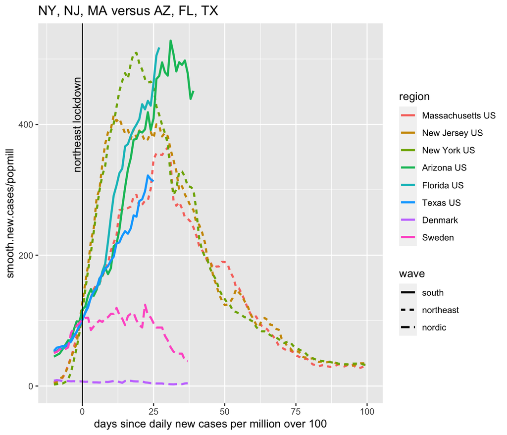

| region | death.per.100 |
| --- | --- |
| Essex New Jersey US | 0.2600832 |
| NYC New York US | 0.2799150 |
| Suffolk Massachusetts US | 0.1271291 |

| region | max.pos | curr.pos |
| --- | --- | --- |
| Nassau New York US | 1005.7411 | 35.26885 |
| Suffolk New York US | 983.5329 | 46.82569 |
| Westchester New York US | 981.3154 | 38.39031 |
| Bergen New Jersey US | 708.6140 | 35.40005 |
| Suffolk Massachusetts US | 639.1997 | 60.06381 |
| Essex New Jersey US | 628.1262 | 25.03207 |
| NYC New York US | 625.4357 | 36.46476 |
| Fairfield Connecticut US | 515.3465 | 18.62698 |
| Middlesex New Jersey US | 508.1869 | 33.20963 |
| Essex Massachusetts US | 474.9026 | 38.38328 |
| New Haven Connecticut US | 357.1608 | 24.06699 |
| Middlesex Massachusetts US | 354.9050 | 31.64363 |
| Worcester Massachusetts US | 320.9299 | 30.26991 |
| Hartford Connecticut US | 262.4142 | 22.10816 |

| region | max.pos |
| --- | --- |
| Miami-Dade Florida US | 985.6151 |
| Broward Florida US | 747.5797 |
| Duval Florida US | 590.5179 |
| Lee Florida US | 513.9006 |
| Hillsborough Florida US | 499.9138 |
| Palm Beach Florida US | 442.9538 |
| Dallas Texas US | 431.4688 |
| Pinellas Florida US | 398.8295 |
| Clark Nevada US | 325.8334 |
| Riverside California US | 311.0938 |
| Fulton Georgia US | 307.2148 |
| DeKalb Georgia US | 305.9221 |
| Mecklenburg North Carolina US | 304.0209 |
| Harris Texas US | 294.4843 |
| Milwaukee Wisconsin US | 280.9633 |
| Salt Lake Utah US | 259.8775 |
| Oklahoma Oklahoma US | 257.9703 |
| Franklin Ohio US | 215.5731 |
| Wake North Carolina US | 205.8510 |

We can compare the 7-day average new cases per day per million people for these metropolitan counties to the counties with Phoenix, Houston, San Antonio and Miami. The Phoenix, Houston, San Antonio and Miami lines are the solid line. It would appear, at this early stage, that these cities are following the pattern of the other cities that had epidemics and we can use that to make a guess at what’s ahead in Florida, Arizona and Texas.

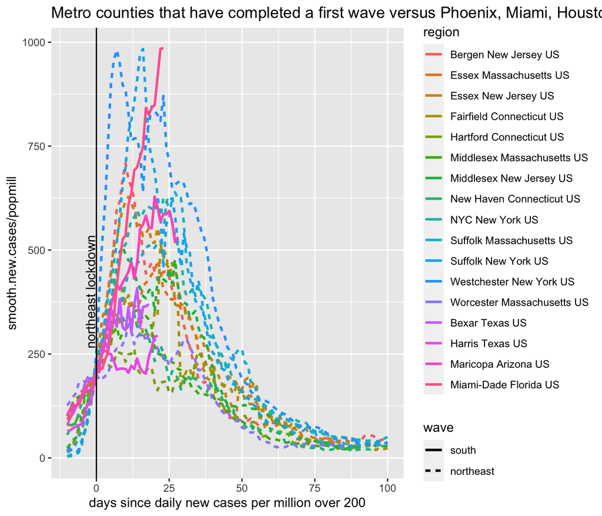

## Where are Arizona, Texas and Florida headed?

Using the patterns seen in the northeast outbreaks, we can make a guess at the mortalities and total cases to expect in the current outbreaks in the south/southwest. These estimates are probably a lower bound however. At around day 0 (when new cases per million were close to 100), NY, NJ, and MA employed a strict lockdown to stop their epidemics. AZ has gone well past that threshold without any severe mitigations, like a “shelter in place” order. Only recently were cities in Texas allowed to impose their own stricter regulations to enforce social distancing. We have yet to see a cases where a city was not put into lockdown to stop a coronavirus epidemic once is got out of control. So we are entering new territory here. Though Sweden is often touted as a country that did not employ mitigations, that’s not true. They didn’t lockdown like the rest of Europe, but certainly employed a variety of mitigations to reduce spread and have never entered a “flash” phase where they lost control of the epidemic in the way that we are seeing in some US states (see the first plot).

### Mortality patterns

In the northeast, mortality started rising 7 (NY) to 14 (MA) days after cases started rising and it was only after daily new cases per million reached 100 (this is 10 on the graph because I divided new cases by 10) that the death curves started increasing. In NJ, this is really apparent. Reported deaths seem fine, fine, fine and then they started zooming up when daily new cases per million hit 200. Why the delay? First, people are on ventilators for a long time before dying and there are delays in death reporting. There are a few layers reporting (hospital, county, then state) before it appears on the state-wide lists. Some states have longer reporting delays than others.

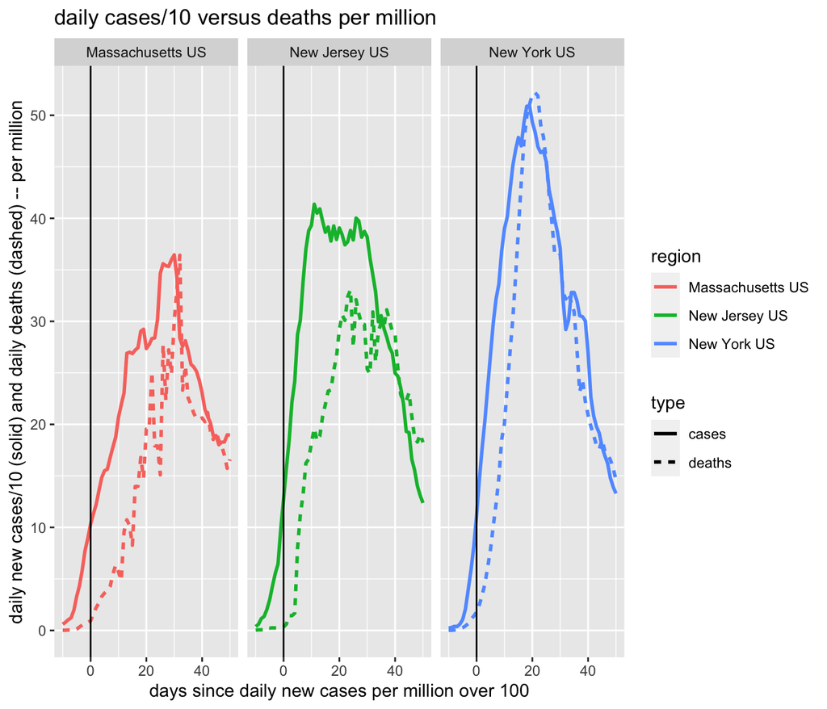

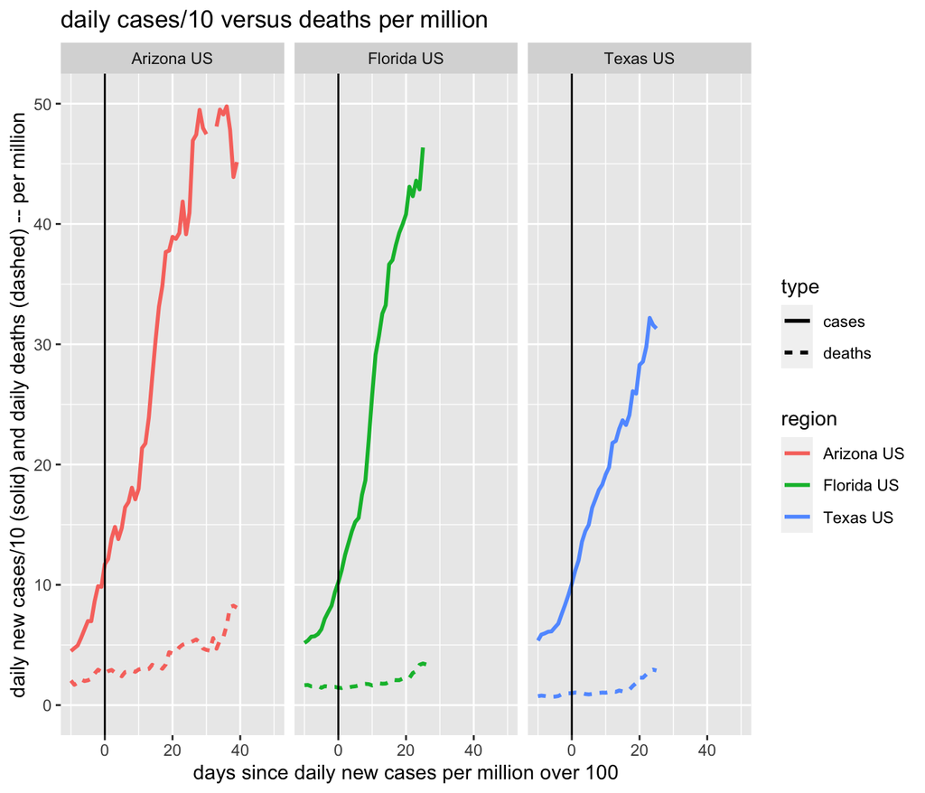

### Expected Mortality and Cases

| region | positive.per.100 | deaths.per.100 |
| --- | --- | --- |
| Massachusetts US | 1.626840 | 0.1211896 |
| New Jersey US | 1.980536 | 0.1754297 |
| New York US | 2.072500 | 0.1665916 |

**Metro counties that have experienced a large epidemic**

| region | positive.per.100 | deaths.per.100 |
| --- | --- | --- |
| Bergen New Jersey US | 2.135481 | 0.2179785 |
| Essex Massachusetts US | 2.094967 | 0.1441003 |
| Essex New Jersey US | 2.385306 | 0.2600832 |
| Fairfield Connecticut US | 1.797882 | 0.1468200 |
| Hartford Connecticut US | 1.340107 | 0.1563271 |
| Middlesex Massachusetts US | 1.526340 | 0.1193151 |
| Middlesex New Jersey US | 2.071238 | 0.1671390 |
| New Haven Connecticut US | 1.476092 | 0.1271706 |
| NYC New York US | 2.634291 | 0.2799150 |
| Suffolk Massachusetts US | 2.535865 | 0.1271291 |
| Suffolk New York US | 2.858863 | 0.1349721 |
| Westchester New York US | 3.655378 | 0.1483195 |
| Worcester Massachusetts US | 1.530179 | 0.1156964 |

The state estimates based on what NY, NJ, and MA experienced are 2.1, 3.4, 6 times higher for AZ, FL, and TX than current deaths on the low end and 3.1, 4.9, 8.6 times higher than current reported deaths on the high end.

**Estimated mortalities based on epidemics in NY, NJ and MA**

| region | current.cases | min.cases | max.cases | current.deaths | min.deaths | median.deaths | max.deaths |
| --- | --- | --- | --- | --- | --- | --- | --- |
| Arizona US | 128097 | 118413 | 150851 | 2365 | 5041 | 6929 | 7297 |
| Florida US | 291629 | 349408 | 445126 | 4418 | 14874 | 20446 | 21530 |
| Texas US | 279577 | 471717 | 600940 | 3362 | 20080 | 27603 | 29067 |

The metro county estimates (only deaths shown) based on what other metro counties have experienced are

**Estimated mortalities based on epidemics in other metro counties**

| region | current.deaths | min.deaths | median.deaths | max.deaths |
| --- | --- | --- | --- | --- |
| Broward Florida US | 464 | 1291 | 1638 | 3123 |
| Clark Nevada US | 498 | 1499 | 1902 | 3626 |
| Dallas Texas US | 477 | 1742 | 2211 | 4216 |
| DeKalb Georgia US | 183 | 502 | 637 | 1215 |
| Duval Florida US | 87 | 633 | 804 | 1532 |
| Franklin Ohio US | 449 | 871 | 1105 | 2106 |
| Fulton Georgia US | 327 | 703 | 893 | 1702 |
| Harris Texas US | 473 | 3116 | 3954 | 7539 |
| Hillsborough Florida US | 189 | 973 | 1235 | 2354 |
| Lee Florida US | 203 | 509 | 646 | 1233 |
| Mecklenburg North Carolina US | 163 | 734 | 932 | 1776 |
| Miami-Dade Florida US | 1175 | 1796 | 2279 | 4346 |
| Milwaukee Wisconsin US | 402 | 625 | 793 | 1513 |
| Oklahoma Oklahoma US | 75 | 527 | 669 | 1276 |
| Palm Beach Florida US | 624 | 990 | 1256 | 2394 |
| Pinellas Florida US | 262 | 645 | 818 | 1560 |
| Riverside California US | 553 | 1633 | 2073 | 3952 |
| Salt Lake Utah US | 130 | 767 | 974 | 1856 |
| Wake North Carolina US | 76 | 735 | 933 | 1778 |

Here are the predicted deaths in graphical form.

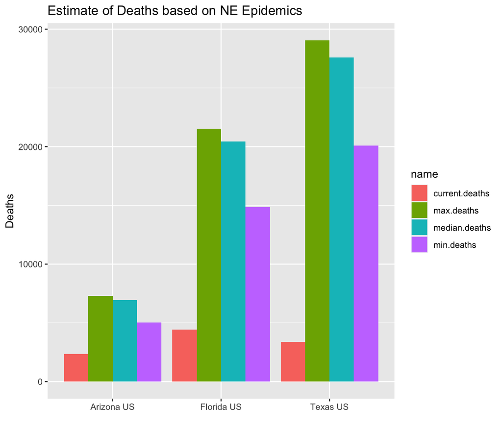